# L01 Visualization

### Exercise 5

Construct a histogram of the `carat` variable in the `diamonds` dataset. Adjust the `bins` to an appropriate value. Add a `title`, remove the axis label that says `count`, and add a `caption`: “Source: ggplot2 package”.

**Solution**

Created both two histograms, one with 0.05 bin width and the other with 0.1 bin width. Both are okay, but I personally would likely go with the 0.1 bin width histogram plot as it is a little less busy and still shows the overall trend pretty well.

```r
# taking a look at data
glimpse(diamonds)
```

```
Rows: 53,940
Columns: 10
$ carat   <dbl> 0.23, 0.21, 0.23, 0.29, 0.31, 0.24, 0.24, 0.26, 0.22, 0.23, 0.…
$ cut     <ord> Ideal, Premium, Good, Premium, Good, Very Good, Very Good, Ver…
$ color   <ord> E, E, E, I, J, J, I, H, E, H, J, J, F, J, E, E, I, J, J, J, I,…
$ clarity <ord> SI2, SI1, VS1, VS2, SI2, VVS2, VVS1, SI1, VS2, VS1, SI1, VS1, …
$ depth   <dbl> 61.5, 59.8, 56.9, 62.4, 63.3, 62.8, 62.3, 61.9, 65.1, 59.4, 64…
$ table   <dbl> 55, 61, 65, 58, 58, 57, 57, 55, 61, 61, 55, 56, 61, 54, 62, 58…
$ price   <int> 326, 326, 327, 334, 335, 336, 336, 337, 337, 338, 339, 340, 34…
$ x       <dbl> 3.95, 3.89, 4.05, 4.20, 4.34, 3.94, 3.95, 4.07, 3.87, 4.00, 4.…
$ y       <dbl> 3.98, 3.84, 4.07, 4.23, 4.35, 3.96, 3.98, 4.11, 3.78, 4.05, 4.…
$ z       <dbl> 2.43, 2.31, 2.31, 2.63, 2.75, 2.48, 2.47, 2.53, 2.49, 2.39, 2.…
```

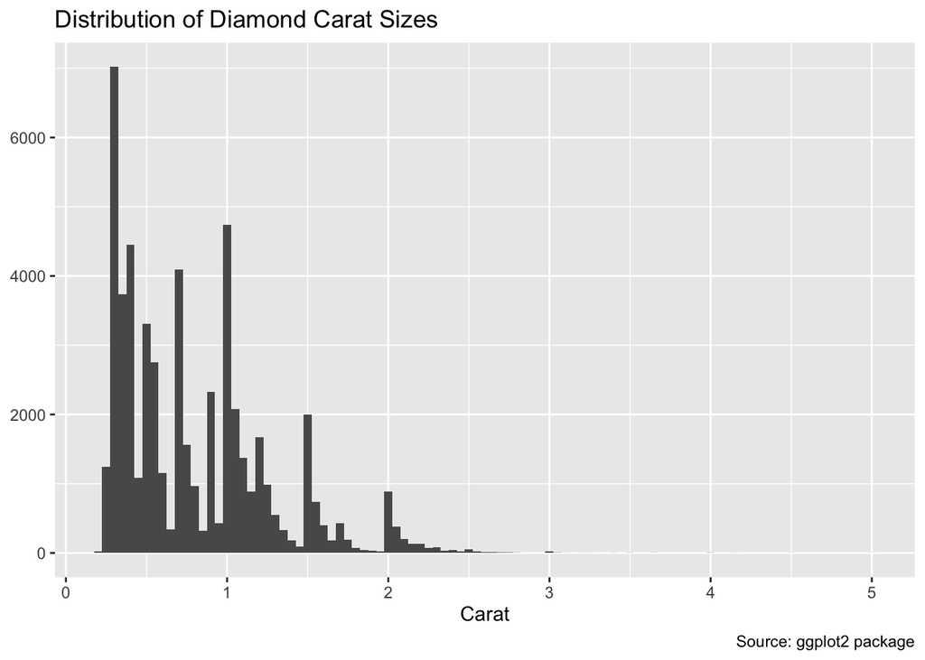

```r
# histogram of diamond carat sizes with 0.05 binwidth
ggplot(
  data = diamonds, mapping = aes(x = carat)) +
  geom_histogram(binwidth = 0.05) +
  labs(
    title = "Distribution of Diamond Carat Sizes",
    x = "Carat",
    y = NULL,
    caption = "Source: ggplot2 package"
  )
```

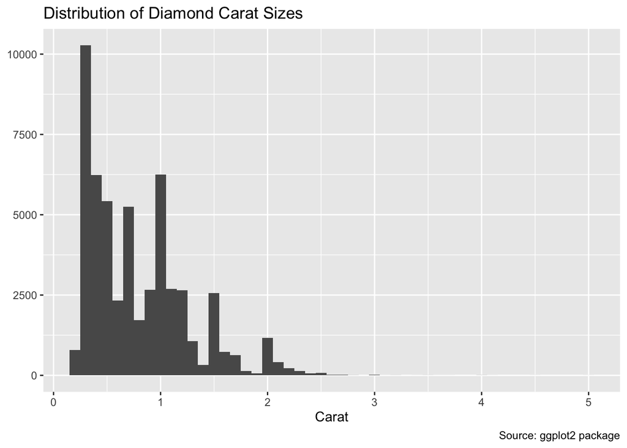

```r
# histogram of diamond carat sizes with 0.1 binwidth
ggplot(
  data = diamonds, mapping = aes(x = carat)) +
  geom_histogram(binwidth = 0.1) +
  labs(
    title = "Distribution of Diamond Carat Sizes",
    x = "Carat",
    y = NULL,
    caption = "Source: ggplot2 package"
  )
```

### Exercise 6

Construct 2 appropriate graphics to show the relationship between `carat` and `cut`.

**Solution**

Initially tried boxplot, but found the distribution hard to interpret so went with violin and ridgeplot that both better visualized the distribution of carat size and cut quality.

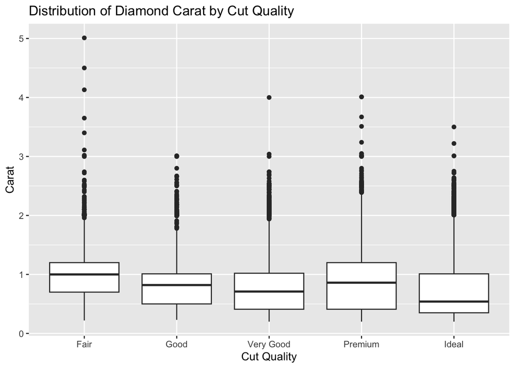

```r
#boxplot to display distribution shape of carat size and cut quality
ggplot(
  data = diamonds,
  mapping = aes(x = cut, y = carat)) +
  geom_boxplot() +
  labs(
    title = "Distribution of Diamond Carat by Cut Quality",
    x = "Cut Quality",
    y = "Carat"
  )
```

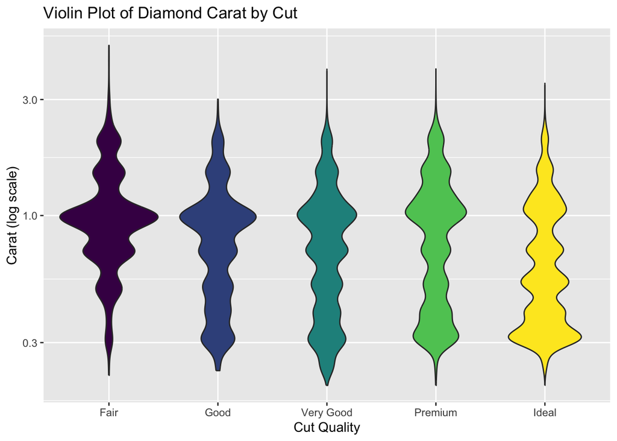

```r
#violin plot to display distribution shape of carat size and cut quality
ggplot(
  data = diamonds,
  mapping = aes(x = cut, y = carat, fill = cut)) +
  geom_violin() +
  scale_y_log10() +
  theme(legend.position = "none") +
  labs(
    title = "Violin Plot of Diamond Carat by Cut",
    x = "Cut Quality",
    y = "Carat (log scale)"
  )
```

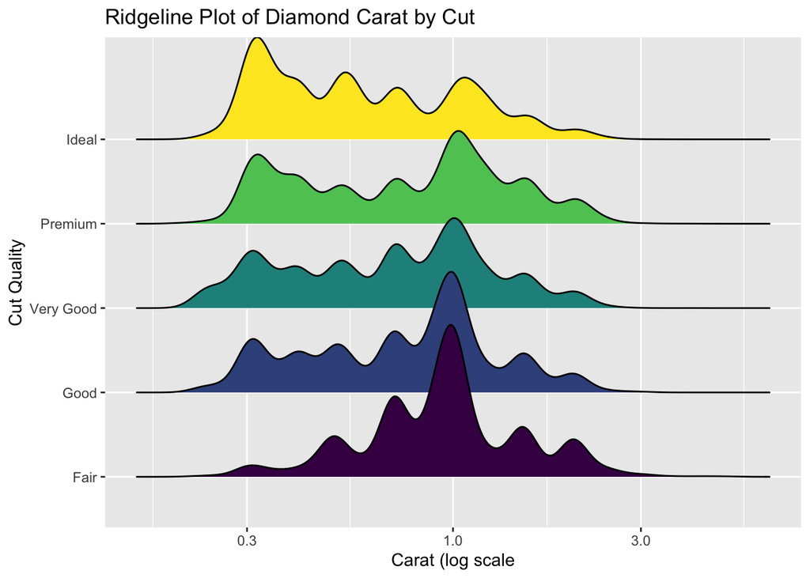

```r
#ridgeplot using alternate method to display distribution of carat size and cut quality, using ggridges library loaded above
ggplot(
  data = diamonds,
  mapping = aes(x = carat, y = cut, fill = cut)) +
  geom_density_ridges() +
  scale_x_log10() +
  theme(legend.position = "none") +
  labs(
    title = "Ridgeline Plot of Diamond Carat by Cut",
    x = "Carat (log scale",
    y = "Cut Quality"
  )
```

### Exercise 7

Construct a barplot of `cut`. Add in `aes(fill = carat > 0.7)`.

**Solution**

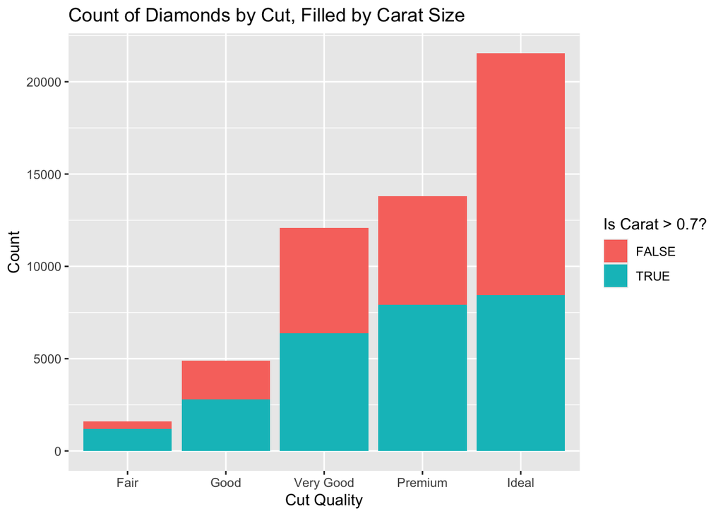

```r
# barplot of diamond cut stratified by carat > 0.7
ggplot(
  data = diamonds,
  mapping = aes(x = cut, fill = carat > 0.7)) +
  geom_bar() +
  labs(
    title = "Count of Diamonds by Cut, Filled by Carat Size",
    x = "Cut Quality",
    y = "Count",
    fill = "Is Carat > 0.7?"
)
```

### Exercise 8

When would you use `facet_grid()` versus `facet_wrap()`? When using `facet_grid()` it is suggested that you put the variable with more unique levels in the columns. Why do you think that this practice is suggested?

**Solution**

You would use facet_wrap() when you want to create subplots based on a single categorical variable. It arranges the plots in an optimal layout, “wrapping” them into multiple rows to best fit the space.

You would use facet_grid() when you want to create a rigid grid of plots based on two categorical variables, with one variable defining the rows and the other defining the columns, which is useful for seeing every possible combinations of the two variables.

When using facet_grid(), I believe the reason that it is recommended that you put the variable with more unique levels in the columns is because computer screens are usually wider than they are tall and is way to utilized the horizontal space more efficiently, creating a plot that is easier to read without excessive vertical scrolling.

## Case Study

Congratulations, you just landed your first job as a data analyst for Tinder! The dataset is stored in the `data` folder called `tinder_data`. A codebook, `tinder_data_codebook.csv`, provides a description of each of the variable names. This has been read in for you at the top of the document. We will learn more about importing data later in the quarter.

**Your first assignment is to determine if there is a relationship between messages sent and messages received and how this differs based on user gender.** Your boss has asked for a one paragraph summary with graphics to support your conclusions. Your boss wants all graphics *saved* into a folder named “plots”. Hint: `ggsave()`.

Since this is your first project as a data analyst you have been provided some tips and considerations for getting started:

- When approaching a research question it is important to use univariate, bivariate, and multivariate analysis (depending on the problem) to get a better understanding of your data and also identify any potential problems.
- How might the distribution of your variables impact your conclusions? Outliers? Weird values? Imbalanced classes?
- How might `coord_fixed()` and `geom_abline()` improve a graphic?
- Feel free to be creative! It is your job to answer this question and interpret conclusions in the most appropriate ways you see fit.

This dataset was provided by [Swipestats.io](https://www.swipestats.io/).

**Solution**

[figure not shown]

```r
# --- SETUP ---

# Load all necessary packages for the analysis.
library(tidyverse)
library(scales)
```

```r
# --- DATA PREPARATION ---

# Load the raw dataset also loaded above
tinder_data <- read.csv("data/tinder_data.csv")

# Clean the data by removing the single row where user_gender is NA observed when glimpsing data.
tinder_data_cleaned <- tinder_data %>%
  tidyr::drop_na(user_gender)
```

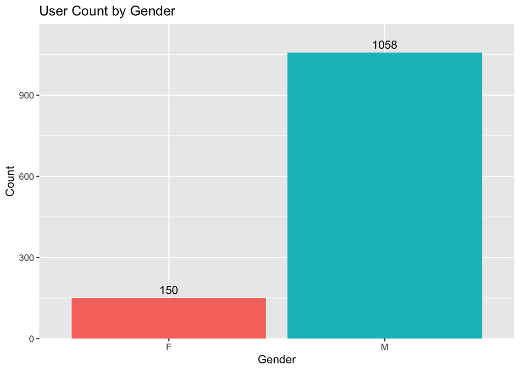

```r
# --- EXPLORATORY ANAYLSIS - GENDER DISTRIBUTION---

# Create bar chart to visualize the number of users in each gender category.
plot_gender_counts <- tinder_data_cleaned %>%
  count(user_gender) %>%
  ggplot(aes(x = user_gender, y = n, fill = user_gender)) +
  geom_col(show.legend = FALSE) +
  geom_text(aes(label = n), vjust = -0.5) +
  scale_y_continuous(expand = expansion(mult = c(0, 0.1))) +
  labs(
    title = "User Count by Gender",
    x = "Gender",
    y = "Count"
  )

# Display the plot
plot_gender_counts
```

```r
# --- EXPLORATORY ANALYSIS - MESSAGES SENT/RECEIVED DISTRIBUTION ---

# Print summary statistics for messages sent
message("Summary Statistics for Messages Sent:")
summary(tinder_data_cleaned$messages_sent)
```

```
    Min.  1st Qu.   Median     Mean  3rd Qu.     Max.
    0.00    12.75   352.00  1606.54  1486.25 61881.00
```

```r
# Print summary statistics for messages received
message("\nSummary Statistics for Messages Received:")
summary(tinder_data_cleaned$messages_received)
```

```
   Min. 1st Qu.  Median    Mean 3rd Qu.    Max.
    0.0    12.0   324.5  1531.4  1426.0 55608.0
```

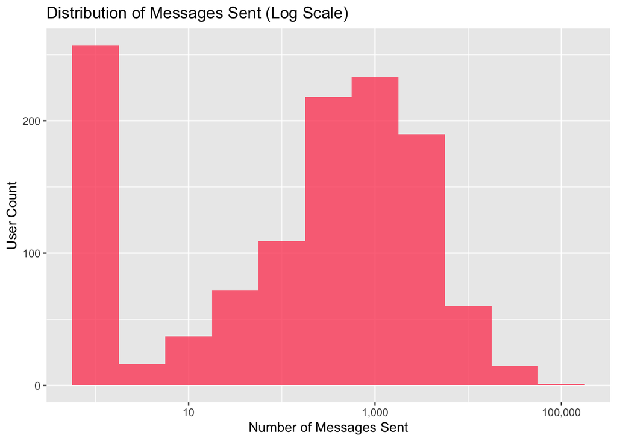

```r
# Histogram of messages sent using a log scale for readability.
plot_sent_dist <- ggplot(data = tinder_data_cleaned, aes(x = messages_sent + 1)) +
  geom_histogram(binwidth = 0.5, fill = "#FD5068", alpha = 0.8) +
  scale_x_log10(labels = label_number(big.mark = ",")) +
  labs(
    title = "Distribution of Messages Sent (Log Scale)",
    x = "Number of Messages Sent",
    y = "User Count"
  )

# Display the plot
plot_sent_dist
```

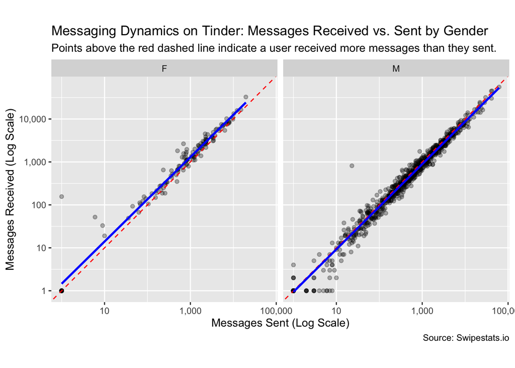

```r
# --- MULTIVARIATE ANALYSIS ---

# Relationship between messages sent and received by gender
final_plot <- ggplot(
  data = tinder_data_cleaned,
  mapping = aes(x = messages_sent + 1, y = messages_received + 1)
) +
  # Use points with transparency to mitigate overplotting
  geom_point(alpha = 0.3) +

  # Add a y=x line for reference. Points above this line received more messages.
  geom_abline(intercept = 0, slope = 1, linetype = "dashed", color = "red") +

  # Add a linear trend line to show the average relationship for each gender
  geom_smooth(method = "lm", se = FALSE, color = "blue") +

  # Use log scales to properly visualize the skewed data and format labels
  scale_x_log10(labels = label_number(big.mark = ",")) +
  scale_y_log10(labels = label_number(big.mark = ",")) +

  # Ensure a 1:1 aspect ratio for an accurate interpretation of the y=x line
  coord_fixed() +

  # Separate the plot into panels for each gender
  facet_wrap(~ user_gender) +

  # Add informative labels and a captions
  labs(
    title = "Messaging Dynamics on Tinder: Messages Received vs. Sent by Gender",
    subtitle = "Points above the red dashed line indicate a user received more messages than they sent.",
    x = "Messages Sent (Log Scale)",
    y = "Messages Received (Log Scale)",
    caption = "Source: Swipestats.io"
  )

# Display the final plot
final_plot
```

```r
# --- SAVE PLOTs ---

# Define the output directory path before using it
PLOTS_DIR <- "plots"

# Ensure output directory exists before trying to save to it.
if (!dir.exists(PLOTS_DIR)) {
  dir.create(PLOTS_DIR)
}

# --- Save all plot objects to the directory ---

# 1. Save the gender distribution bar chart
ggsave(
  filename = file.path(PLOTS_DIR, "gender_distribution.png"),
  plot = plot_gender_counts,
  width = 6,
  height = 5,
  dpi = 300
)

# 2. Save the messages sent histogram
ggsave(
  filename = file.path(PLOTS_DIR, "messages_sent_distribution.png"),
  plot = plot_sent_dist,
  width = 8,
  height = 5,
  dpi = 300
)

# 3. Save the final multivariate plot
ggsave(
  filename = file.path(PLOTS_DIR, "tinder_messaging_by_gender.png"),
  plot = final_plot,
  width = 10,
  height = 6,
  dpi = 300
)
```

## Graduate Challenge

**Important**

Graduate students are required to complete this challenge. **It is optional for undergraduate students.**

- alpha = 0.25
- theme is with Google Docs Chart from [ggthemes package](https://jrnold.github.io/ggthemes/reference/index.html).